# Leveraging External Evidence in Clinical Trials via Dynamic Borrowing from a Single Prior Study (or single source of virtual patients)

April 3, 2019

## Outline

- Background of Leveraging Prior Data for Medical Device Trials
- Conditional Power Prior and Discount Prior Method (Haddad, Himes, Thompson et al. 2017)
  - Recent (ongoing) variations
  - Simulation Results
- Summary

## Use of External Data as Prior Information

- Taking advantage of prior information (e.g., prior studies) can potentially reduce the sample size needed for a new trial.
- Possible sources of prior information:
  - previous studies, foreign clinical data, in-silico models, similar population
- Bayesian methods can be used to formally incorporate prior information
- The prior information should not overwhelm the current study
  - Down-weight strength of prior data via dynamic borrowing
  - Borrowing strength diminishes if there is conflict between prior and current data

## Types of leveraging methods

- Bayesian hierarchical modeling
  - Multiple studies, populations or subgroups
- Commensurate prior (Hobbs & Carlin); Meta-analytic predictive approach (Neunschwander, et al.)
- Power prior method: Good with a single prior data source (Ibrahim & Chen)
  - Discount Power Prior to integrate “virtual patients” into a clinical trial (Haddad, Thompson et al. 2017)
  - Borrowing is adaptive or dynamic: Depends on similarity of outcomes between prior and current studies.

## Review of Conditional Power Prior (CPP)

### Prior Distribution on \(\theta\) given *D*<sub>0</sub>

\[\color{black}{\large{ {\pi ^{CPP}}(\theta |{D_0},\color{red}{\alpha _0}) \propto {L_0}{(\theta |{D_0})^{ \color{red}{\alpha _0}}}\pi (\theta )}, \,\,\, 0 \le \alpha_0 \le 1} \]

### Posterior Distribution on \(\theta\) (after observing *D*)

\[\color{black}{\large{\pi (\theta |D,{{D}_{0}},{{\alpha }_{0}})\propto {{L}_{0}}{{(\theta |{{D}_{0}})}^{{{\alpha }_{0}}}}\pi (\theta ) \color{red}{L(\theta |D)} }}\]

#### Power parameter (\(\alpha_0\)) is a “discounting factor” that down-weights a prior study, from all \((\alpha_0 = 0)\) to none \((\alpha_0 = 1)\)

#### \(\alpha\)<sub>0</sub> can convey an **effective sample size** of the prior study

## Discount Prior Method (Haddad et al., 2017)

#### **Prior on \(\theta\) (success rate) given *D*<sub>0</sub> (and *D*)**

\[\color{black}{\large{\pi ^{CPP}(\theta |{D_0},D) \propto L_0(\theta |{D_0})^{\color{red}{\alpha_{0}(D_0,\,D)}}\pi (\theta )}}\]

\[\large{\color{red}{\alpha_{0}(D_0,\,D)} = 1 -\exp(-(\frac{\color{red}{p(D_0,\,D)}}{\lambda})^k) \le M \le 1}\]

where

\(\large{\color{red}{p(D_0,\,D) = p} = P({\theta }>{{\theta }_{0}}|\,{{D}_{0}},\,{D}) = P({\theta }-{{\theta }_{0}} > 0|\,{{D}_{0}},\,{D})}\)

\(\,\,\, \large{\theta}\) ~ \(\large{\pi(\theta | D) \propto L(\theta | D)\pi(\theta)}\)

\(\large{\theta_0}\) ~ \(\large{\pi(\theta | D_0) \propto L_0(\theta | D_0)\pi(\theta)}\) \(\,\,\,\,\,\)

## Comments on Discount Prior Method

1. The current data are used twice, both in the prior and in the likelihood. Potential implication to artifically increase precision.
2. The prior is fully determined *a posteriori*. (Is this legitimately Bayesian?)
3. A “stochastic ordering” measure of similarity may be influenced by the current data sample size so that more prior information is borrowed when the sample size is smaller.

## “Double Use”: Use an interim subset (\(\small{D_1}\)) in \(\small{\alpha_0}\)

#### Size of *D*<sub>1</sub> is *n*<sub>1</sub> = %*n*. Then, *D* = [*D*<sub>1</sub>, *D*<sub>2</sub>].

#### Prior on \(\theta\) given *D*<sub>0</sub> (and *D*<sub>1</sub>):

\[\color{black}{\large{\begin{align} & {{\pi }^{CPP}}(\theta |{{D}_{0}},{{D}_{1}})\propto {{L}_{0}}{{(\theta |{{D}_{0}})}^{{{\alpha }_{0}}({{D}_{0}},\color{red}{{D}_{1}})}}\pi (\theta ) \color{red}{L(\theta |{{D}_{1}})} \\ \end{align}}}\]

#### Posterior given remaining current data *D*<sub>2</sub>:

\[\color{black}{\large{\begin{align} & \pi (\theta |{{D}_{0}},{{D}_{1}},{{D}_{2}})\propto \\ & \,\,\,\,\,\,\,\,\,\,\,\,\, L_0{{(\theta |{{D}_{0}})}^{{{\alpha }_{0}}({{D}_{0}},{{D}_{1}})}}\pi (\theta )L(\theta |{{D}_{1}}) \color{red}{L(\theta |{{D}_{2}})} \\ \end{align}}}\]

#### If *D*<sub>1</sub> is considered a “second” prior data set, CPP is a legitimate prior on \(\theta\), before observing *D*<sub>2</sub>.

## Measuring Similarity of Prior and Current Data

##### **Hypothetical Posterior Distribution of \(\small{\theta} - \small{{{\theta }_{0}}}\) for Success Rate**

[figure not shown]

Shaded is \(\small{P(\theta - {{\theta }_{0}} > 0 |{{D}_{0}},D)}\)

Borrow more with *smaller*  
current data sample size (anti-conservative?)

## Alternative Measure of Similarity

\[\color{black}{\large{\pi ^{CPP}(\theta |{D_0},D_1) \propto L_0(\theta |{D_0})^{\alpha_{0}(D_0,\,\color{red}{D_1})}\pi (\theta )}}\]

\[\large{\alpha_{0}(D_0,\,\color{red}{D_1}) = \left\{ \begin{align} & 1 -\exp(-(\frac{p}{\lambda})^k) \\ & p \,\,\, (\text{identity}) \\ \end{align} \right. \,\,\,\,\,\, \le M \le 1}\]

\(\large{p = P(|{\theta }-{{\theta }_{0}}| < \color{red}{\delta}|\,{{D}_{0}},\,\color{red}{D_1}), \text{ if} }\) \(\large{\color{red}{|{\bar D_0} - {\bar D_1}| < \delta},}\) else \(\large{p = 0}\)

\(\,\,\, \large{\theta}\) ~ \(\large{\pi(\theta | D_1) \propto L(\theta | D_1)\pi(\theta)}\)

\(\large{\theta_0}\) ~ \(\large{\pi(\theta | D_0) \propto L_0(\theta | D_0)\pi(\theta)}\)

#### \(\small{\delta}\) is a “similarity margin”: If \(\small{|{\theta }-{{\theta }_{0}}| < \delta}\), current and prior data are “similar”.

## Alternative Measure of Similarity

##### **Hypothetical Posterior Distribution of \(\small{\theta} - \small{{{\theta }_{0}}}\) for Success Rate**

[figure not shown]

##### Shaded is \(\small{P(|\theta - {{\theta }_{0}}| < \delta |{{D}_{0}},D)}\)

Now, worse data can overwhelm  
the prior (conservative)

\(\scriptsize{0<\theta-\theta_0<\delta}\)

\(\scriptsize{-\delta <\theta-\theta_0< 0}\)

## Form of \(\small{{{\alpha }_{0}}({{D}_{0}},{{D}_{1}})}\) for Simulations

[figure not shown]

Weibull parameters would be pre-specified at the design stage.

**\(\small{\color{black}{\alpha _0(D_0,D_1)}}\) by \(\small{{{\theta }^{*}}}\)**

[figure not shown]

**Type I Error Rate under \(\color{black}{H_0: \small{ \theta \le \theta^{*} } }\)**

[figure not shown]

**Power under \(\color{black}{H_0: \small{ \theta \le -0.5 } }\)**

[figure not shown]

**Bias = \(\small{{E({\theta }| D_0, D) - \theta^{*} }}\)**

[figure not shown]

## Summary of discount prior methods

- \(\delta\)-similarity region measure has less “double use” of the full set of current data in the final posterior, and may depend less on posterior variance.
  - Type I error rate generally highest inside of the \(\delta\)-region, but lower when an interim data percentage was used to estimate the borrowing fraction.
  - Power was higher when using 100% of the current data (vs less than 100%) to estimate the amount of borrowing .
- Using stochastic ordering measures
  - Somewhat greater power than \(\delta\)-similarity measure
  - Larger increase in bias when current data better than prior data (for 1-sided discount function)
  - Higher type I error rate in region outside of \((-\delta, \delta)\)

## Future Directions for VP Model Validation

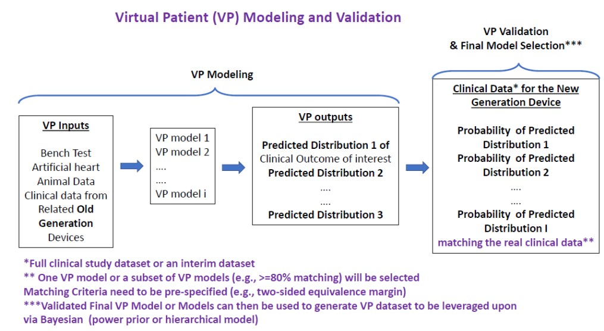

###### Different data sources would provide different inputs (i.e., complexity and diversity).

###### Use an “ensemble” method to combine the model predictions (e.g., bagging, boosting)

## Some Final Thoughts on Leveraging External Evidence

#### With more than one prior data source, several potential methods are viable: hierarchical modeling, meta-analytic prior, power prior.

#### With only one prior data source, the discount power prior should be considered.

#### Covariates may be needed to calibrate the prior and current datasets in order to assume exchangeability.

#### Ultimately, investigating design characteristics is necessary to ensure a reasonable trial design.

**Thank you**